# Chapter 8: Example 14

```r
annaPrior <- list(mean=0.2, sigma=0.08)
```

Three students are constructing their prior belief about $\pi$, the proportion of Hamilton residents who support building a casino in Hamilton. Anna thinks that her prior mean is 0.2, and her prior standard deviation is 0.08.

The parameters of a beta distribution (a, b) are related to $\pi$ and $\sigma$, the mean and standard deviation of the distribution, by the following equation:

$$
$$\begin{array}{rclr}
\pi_0 &=& \dfrac{a}{a + b} & \text{def}\\
b &=& \dfrac{a}{\pi_0}-a&\\
\\
\sigma_0 &=& \sqrt{\dfrac{\pi_0 (1 - \pi_0)}{a + b + 1}} & \text{def}\\
\sigma_0 &=& \sqrt{\dfrac{\pi_0 (1 - \pi_0)}{a + (\frac{a}{\pi_0}-a)+1}}
= \sqrt{\dfrac{\pi_0 (1 - \pi_0)}{\frac{a}{\pi_0}+1}} &\\
a &=& \dfrac{\pi_0^2 (1 - \pi_0)}{\sigma_0^2} - \pi_0 &
\end{array}$$

[figure not shown]

```r
bartPrior <- list(
  a = 1,
  b = 1
)
```

Bart is a newcomer to Hamilton, so he is not aware of the local feeling for or against the proposed casino. He decides to use a uniform prior. For him, $a = b = 1$. His equivalent sample size is $a + b + 1 = 3$.

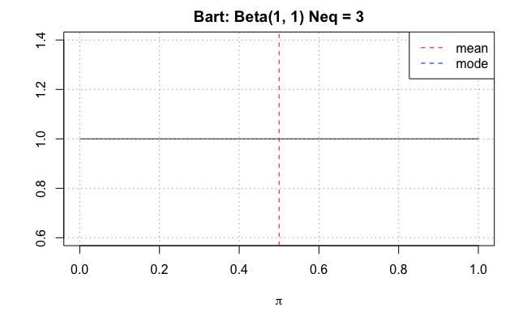

```r
with(bartPrior, {
  bartPrior["mean"] <<- a / (a + b)
})
with(bartPrior, {
  plot(
    x, dbeta(x, a, b),
    type="l",
    xlab = expression(pi),
    ylab = ""
  )
  title(
    paste0(
      "Bart: Beta(1, 1)",
      " Neq = ", round(a + b + 1, 2)
    )
  )
  abline(v = c(mean), col=plotParam$col, lty=plotParam$lty)
  grid(col = "darkgrey")
  legend("topright", plotParam$text, col=plotParam$col, lty=plotParam$lty)
})
```

Chris can’t find a beta(a, b) prior to match his belief. He believes his prior probability has a trapezoidal shape. He specifies his prior as:
$$g(\pi) =
\begin{cases}
20\pi & \text{for} & 0 \le \pi \le .10,\\
2 & \text{for} & .10 \le \pi \le .30,\\
5 - 10\pi & \text{for} & .30 \le \pi \le .50,\\
0 & \text{for} & .50 \le \pi \le 1
\end{cases}$$

```r
chrisPriorFun <- function(x) {
  if (x <= 0.1) {
    return(20 * x)
  } else if (x <= 0.3) {
    return(2)
  } else if (x <= 0.5) {
    return(5 - 10 * x)
  } else {
    return(0)
  }
}
chrisPrior <- sapply(x, chrisPriorFun)
chrisMean <- drop(x %*% chrisPrior) / sum(chrisPrior)
plot(
  x, chrisPrior,
  type="l",
  xlab = expression(pi),
  ylab = ""
)
abline(v = c(chrisMean), col=plotParam$col, lty=plotParam$lty)
```

```r
grid(col = "darkgrey")
legend("topright", plotParam$text, col=plotParam$col, lty=plotParam$lty)
```

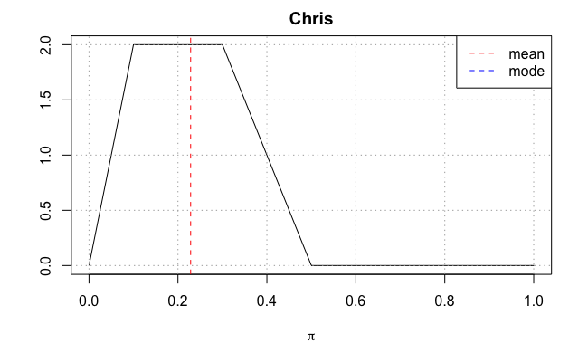

```r
title("Chris")
```

```r
actualPi <- 0.26
sampleSize <- 15
support <- round(sampleSize * actualPi)
oppose <- sampleSize - support
```

The three students take a random sample of $n = 15$ Hamilton residents and find their views on the casino. Out of the random sample, $y=4$ said they support building a casino in Hamilton. Anna’s posterior is $beta(4.8 + 4, 19.2 + 11)$. Bart’s posterior is $beta(1 + 4, 1 + 11)$. Chris’ posterior is found using Equation 8.1. We need to evaluate Chris’ prior numerically. To do this, we integrate Chris’ prior $\times$ likelihood.

$$g(\pi | y) = \dfrac{g(\pi) \times f(y|\pi)}{ \int_0^1 g(\pi) \times f(y|\pi) \; d\pi } \tag{8.1}$$

```r
fYgivenPi <- function(p) {
  return(p^support * (1 - p)^oppose)
}
chrisLikelihood <- sapply(x, fYgivenPi)
chrisPosterior <- chrisPrior * chrisLikelihood / (drop(chrisPrior %*% chrisLikelihood) * step)
# Posterior: Anna
plot(
  x, dbeta(x, annaPrior$a + support, annaPrior$b + oppose),
  type = "l",
  xlab = expression(pi),
  ylab = ""
)
# Posterior: Bart
points(
  x, dbeta(x, bartPrior$a + support, bartPrior$b + oppose),
  type = "l",
  col = "red"
)
```

```r
# Posterior: Chris
points(
  x, chrisPosterior,
  type = "l",
  col = "blue"
)
# Actual
abline(v = actualPi, lty = 5)
```

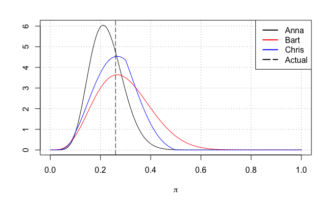

```r
grid(col = "darkgrey")
legend(
  "topright",
  legend =  c("Anna", "Bart", "Chris", "Actual"),
  col = c("black", "red", "blue", "black"),
  lty = c(1, 1, 1, 5),
  lwd = c(2, 2, 2, 2)
)
```

```r
# numerical integration
f <- function(values, step) {
  return(sum(values) * step)
}
print(
  paste(
    "check that all distributions integrate to 1: ",
    f(dbeta(x, 4.8 + 25, 19.2 + 74), step),
    f(dbeta(x, 1 + 26, 1 + 74), step),
    f(chrisPosterior, step)
  )
)
```

```
[1] "check that all distributions integrate to 1:  1 1 1"
```